# Factors Influencing Housing Values in Boston

A Exploratory and Regression Analysis

Xiaoying Ma

06/09/2026

Abstract

This report analyzes the factors that influence housing values in the Boston area. The main response variable is **MEDV**, the median value of owner-occupied homes in thousands of dollars. The analysis uses data inspection, distributional exploration, location-related visualization, feature engineering, and regression modeling to study how neighborhood, environmental, accessibility, and river-adjacent characteristics are associated with housing value.

# 1 Introduction:

The **Boston Housing Dataset** contains housing and neighborhood information for census tracts in the Boston Standard Metropolitan Statistical Area. The data include median housing value, crime rate, environmental measures, accessibility measures, school-related variables, and neighborhood characteristics. The response variable selected for regression analysis is **MEDV**, the median value of owner-occupied homes in thousands of dollars.

**Objectives**

This project aims to achieve the following objectives:

- Identify the key factors that significantly influence housing prices in Boston
- Quantify the magnitude and direction of each predictor’s effect on median home value
- Visualize spatial patterns and relationships among housing, environmental, and socioeconomic variables
- Develop a predictive model for estimating Boston housing prices
- Demonstrate the application of the Visualization Framework in housing market analysis

# 2 Data Acquisition and Processing

This dataset contains housing and neighborhood information for census tracts in the Boston metropolitan area. It includes structural, environmental, accessibility, and socidoeconomic variables, while the response variable `medv` records the median value of owner-occupied homes in thousands of dollars.

```
╔══════════════════════════════════════════════════════════════╗
║              DATA ACQUISITION SUMMARY                        ║
╠══════════════════════════════════════════════════════════════╣
║  Dataset:    Boston Housing Dataset                          ║
║  Source:     Kaggle                                          ║
║  Period:     1978                                            ║
║  Geography:  Boston Metropolitan Area                        ║
╚══════════════════════════════════════════════════════════════╝
```

- **Variable Dictionary in the Boston Housing Dataset**

| Variable Name | Description |
| --- | --- |
| TOWN | Town name . |
| CRIM | Per capita crime rate by town . |
| TOWNNO | Town identification number. |
| TRACT | Census tract identifier. |
| CMEDV | Capped median home value. |
| ZN | Proportion of residential land zoned for lots over 25,000 sq.ft. |
| INDUS | Proportion of non-retail business acres per town. |
| CHAS | Charles River dummy variable (1 if tract bounds river; 0 otherwise). |
| NOX | Nitric oxides concentration (parts per 10 million). |
| RM | Average number of rooms per dwelling. |
| AGE | Proportion of owner-occupied units built prior to 1940. |
| DIS | Weighted distances to five Boston employment centres . |
| RAD | Index of accessibility to radial highways. |
| TAX | Full-value property-tax rate per $10,000 . |
| PTRATIO | Pupil-teacher ratio by town . |
| B | 1000(Bk - 0.63)^2 where Bk is the proportion of blacks by town. |
| LSTAT | % lower status of the population. |
| MEDV | Median value of owner-occupied homes in $1000’s. |
| LON | Longitude. |
| LAT | Latitude. |

- **Initial Data Processing**

The initial data processing includes checking for missing values and preparing variable types for later analysis. Since the Boston housing data mainly contain numeric variables, only basic cleaning and simple variable transformation are needed.

```r
housing_clean <- read.csv("BostonHousing.csv")

# Remove index variable created during export
if ("Unnamed: 0" %in% names(housing_clean)) {
  housing_clean <- housing_clean[, !(names(housing_clean) %in% "Unnamed: 0")]
}

dim(housing_clean)
```

```
[1] 506  21
```

```r
head(housing_clean)
```

```
    X      TOWN TOWNNO TRACT    LON   LAT MEDV CMEDV    CRIM ZN INDUS CHAS  NOX    RM  AGE   DIS
1 178 Arlington     29  3567 -77.10 38.87 29.9  29.9 0.06642  0  4.05    0 0.51 6.860 74.4 2.915
2 177 Arlington     29  3566 -77.10 38.88 24.6  24.6 0.05425  0  4.05    0 0.51 6.315 73.4 3.317
3 176 Arlington     29  3565 -77.10 38.88 23.2  23.2 0.07022  0  4.05    0 0.51 6.020 47.2 3.555
4 175 Arlington     29  3564 -77.11 38.89 29.4  29.4 0.06664  0  4.05    0 0.51 6.546 33.1 3.132
  RAD TAX PTRATIO     B LSTAT
1   5 296    16.6 391.3  6.92
2   5 296    16.6 395.6  6.29
3   5 296    16.6 393.2 10.11
4   5 296    16.6 391.0  5.33
 [ reached 'max' / getOption("max.print") -- omitted 2 rows ]
```

```r
# =======================================
#   DATA CLEANING AND TRANSFORMATION
# =======================================

housing_clean <-  housing_clean %>%
  filter(!is.na(MEDV)) %>%
  mutate(
    CHAS = factor(CHAS, levels = c(0, 1), labels = c("No", "Yes"))
  )
```

There are no missing values in this data set. For illustrative purposes, we still show a simple cleaning step by removing observations with missing components if any were present. The data do not show serious missing-value issues. Therefore, only basic cleaning and variable preparation are needed before visual exploration.

# 3 Visual Exploratory Data Analysis

## 3.1 Distributional Patterns of Features

We examine the distributions of categorical and numerical variables to identify predictors that may require regrouping or transformation.

- **Categorical Variables**

There are two main categorical variables in the Boston housing dataset. The variable `CHAS` indicates whether a tract bounds the Charles River (`1 = yes`, `0 = no`).

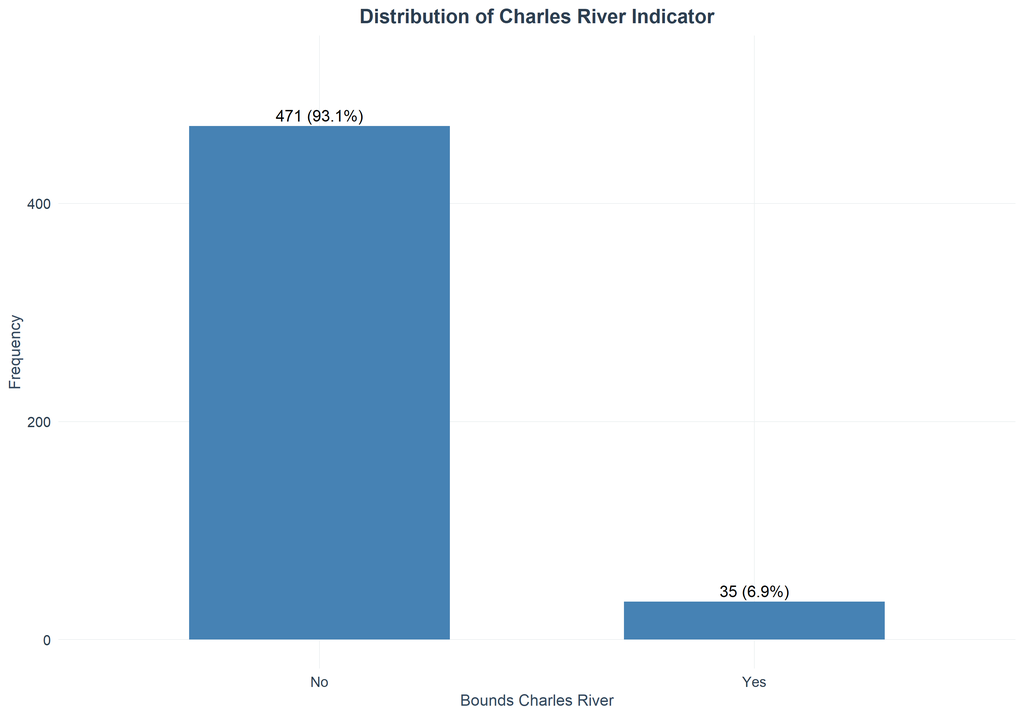

```r
library(ggplot2)

chas_count <- as.data.frame(table(housing_clean$CHAS))
colnames(chas_count) <- c("CHAS", "Count")
chas_count$Percent <- round(chas_count$Count / sum(chas_count$Count) * 100, 1)
chas_count$Label <- paste0(chas_count$Count, " (", chas_count$Percent, "%)")

ggplot(chas_count, aes(x = CHAS, y = Count)) +
  geom_col(fill = "steelblue", width = 0.6) +
  geom_text(aes(label = Label), vjust = -0.4, size = 4) +
  labs(
    title = "Distribution of Charles River Indicator",
    x = "Bounds Charles River",
    y = "Frequency"
  ) +
  expand_limits(y = max(chas_count$Count) * 1.12) +
  my.theme()
```

- **Numerical Variables**

The Boston housing dataset contains many numerical variables. For concise exploratory analysis, we focus on several major predictors with clear practical interpretation: `RM`, `LSTAT`, `NOX`, `DIS`, and the response variable `MEDV`. These variables reflect housing size, socioeconomic status, air pollution, accessibility, and housing value, respectively.

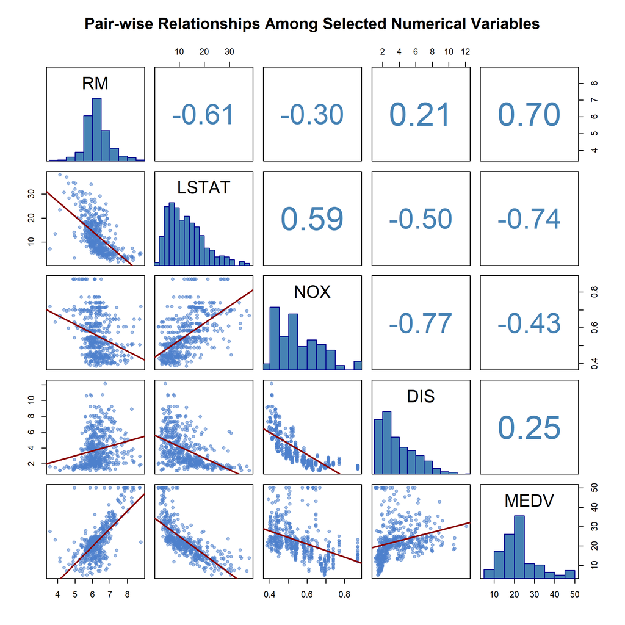

```r
panel.cor <- function(x, y, digits = 2, prefix = "", cex.cor, ...) {
  usr <- par("usr")
  on.exit(par(usr))
  par(usr = c(0, 1, 0, 1))
  r <- cor(x, y, use = "complete.obs")
  txt <- format(c(r, 0.123456789), digits = digits)[1]
  txt <- paste(prefix, txt, sep = "")
  if (missing(cex.cor)) cex.cor <- 0.8 / strwidth(txt)
  text(0.5, 0.5, txt, cex = cex.cor * 0.8, col = "steelblue")
}

panel.hist <- function(x, ...) {
  usr <- par("usr")
  on.exit(par(usr))
  par(usr = c(usr[1:2], 0, 1.5))
  h <- hist(x, plot = FALSE, breaks = 15)
  breaks <- h$breaks
  nB <- length(breaks)
  y <- h$counts
  y <- y / max(y)
  rect(breaks[-nB], 0, breaks[-1], y, col = "steelblue", border = "darkblue")
}

panel.scatter <- function(x, y, ...) {
  points(x, y, pch = 19, col = rgb(0.3, 0.5, 0.8, alpha = 0.5), cex = 0.8)
  abline(lm(y ~ x), col = "darkred", lwd = 2)
}

pairs(
  housing_clean[, c("RM", "LSTAT", "NOX", "DIS", "MEDV")],
  lower.panel = panel.scatter,
  upper.panel = panel.cor,
  diag.panel = panel.hist,
  main = "Pair-wise Relationships Among Selected Numerical Variables"
)
```

The pair-wise plot suggests that `RM`, `LSTAT`, `NOX`, and `DIS` are all related to `MEDV`. In particular, `RM` appears positively associated with housing value, while `LSTAT` and `NOX` show negative associations. The relationship between `DIS` and `MEDV` is also visible, although it appears less linear.

- **Extract Geo-spatial Information**

The Boston housing dataset contains spatial coordinate variables, LON and LAT, which allow us to visually explore geographic patterns in the data. In addition, several neighborhood-related variables, such as DIS (weighted distance to employment centers), RAD (accessibility to radial highways), and CHAS (whether the tract bounds the Charles River), provide further location-related information. Together, these variables help reveal geographic heterogeneity in housing values.

```r
library(leaflet)
library(dplyr)

leaflet(housing_clean) %>%
  addTiles() %>%
  fitBounds(lng1 = -71.25, lat1 = 42.20, lng2 = -70.95, lat2 = 42.45) %>%
  addCircleMarkers(
    lng = ~LON,
    lat = ~LAT,
    radius = 3,
    color = "purple",
    fillOpacity = 0.5,
    popup = ~paste(
      "<b>🏠 Boston Housing Details</b><br>",
      "━━━━━━━━━━━━━━━━━━━<br>",
      "🏘️ Town:", TOWN, "<br>",
      "🌊 Charles River:", CHAS, "<br>",
      "🏚️ Housing Age:", round(AGE, 1), "<br>",
      "🏢 Distance to Employment Centers:", round(DIS, 2), "<br>",
      "🚗 Highway Accessibility (RAD):", RAD, "<br>",
      "🌫️ NOX Concentration:", round(NOX, 3), "<br>",
      "🏠 Average Rooms:", round(RM, 2), "<br>",
      "💰 Median House Value:", MEDV, "<br>",
      "📍 Coordinates:", round(LAT, 4), ", ", round(LON, 4)
    )
  )
```

[interactive chart not shown]

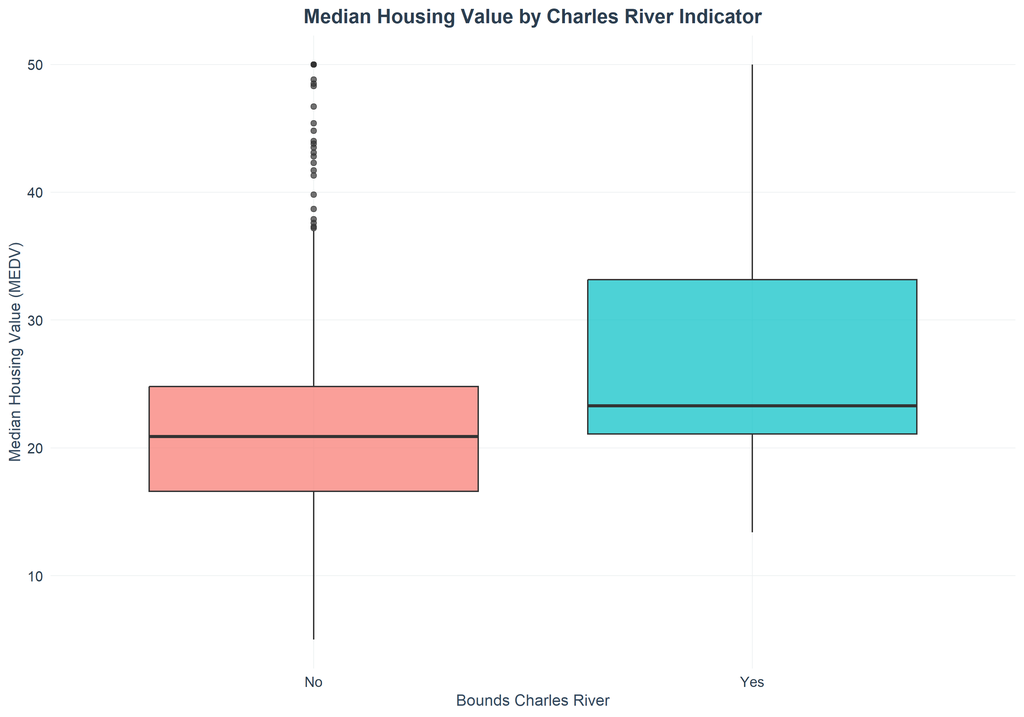

```r
ggplot(housing_clean, aes(x = CHAS, y = MEDV, fill = CHAS)) +
  geom_boxplot(alpha = 0.7) +
  labs(
    title = "Median Housing Value by Charles River Indicator",
    x = "Bounds Charles River",
    y = "Median Housing Value (MEDV)"
  ) +
  guides(fill = "none") +
  my.theme()
```

The boxplot shows that tracts bordering the Charles River may have a different distribution of housing values from those that do not. This suggests that location-related information in the Boston dataset captures meaningful neighborhood heterogeneity and should be considered in the subsequent modeling process.

# 4 Feature Engineering

We construct several categorical variables to facilitate descriptive interpretation in the subsequent analysis. In particular, `NOX` and `DIS` are grouped into three ordered categories based on sample tertiles. We also create a simple spatial grouping variable using the coordinate information, which may help capture broad east-west and north-south neighborhood differences.

```r
housing_clean$NOX_cat <- cut(
  housing_clean$NOX,
  breaks = quantile(housing_clean$NOX, probs = c(0, 1/3, 2/3, 1), na.rm = TRUE),
  include.lowest = TRUE,
  labels = c("Low", "Medium", "High")
)

housing_clean$DIS_cat <- cut(
  housing_clean$DIS,
  breaks = quantile(housing_clean$DIS, probs = c(0, 1/3, 2/3, 1), na.rm = TRUE),
  include.lowest = TRUE,
  labels = c("Short", "Medium", "Long")
)

housing_clean$lon_zone <- ifelse(housing_clean$LON <= median(housing_clean$LON, na.rm = TRUE),
                                 "West", "East")

housing_clean$lat_zone <- ifelse(housing_clean$LAT <= median(housing_clean$LAT, na.rm = TRUE),
                                 "South", "North")

housing_clean$spatial_zone <- factor(paste(housing_clean$lat_zone,
                                           housing_clean$lon_zone,
                                           sep = "-"))
```

The engineered variables provide a more interpretable way to describe environmental exposure, accessibility, and broad geographic location. These variables are particularly useful in the exploratory phase and may also serve as candidate predictors in regression modeling.

## 4.1 Relationship Between Features and the House Value

We now examine whether the selected categorical predictors are associated with median home value. The following boxplots provide a descriptive comparison of `MEDV` across the Charles River indicator, pollution level, accessibility category, and broad spatial zone.

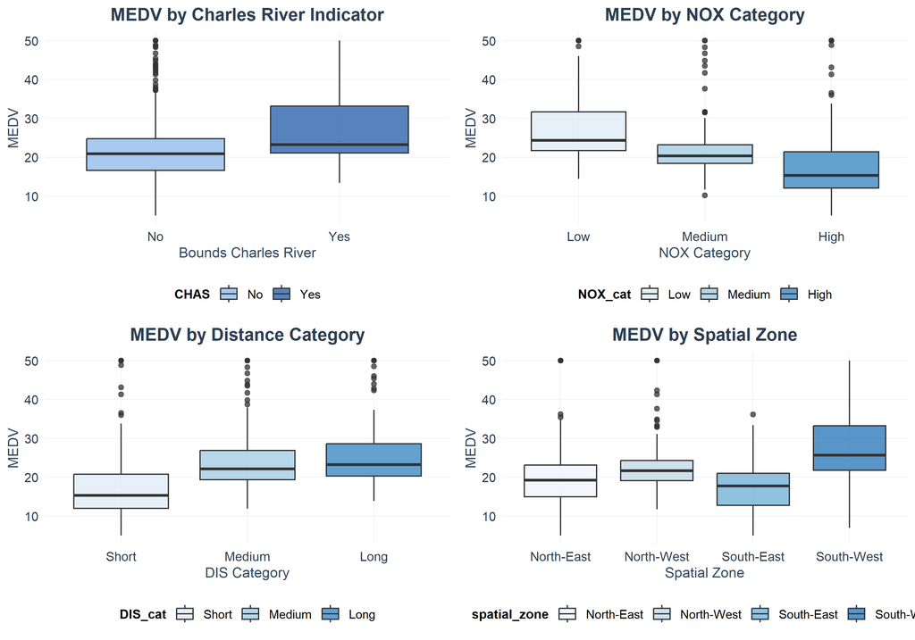

```r
library(dplyr)
library(gridExtra)

library(gridExtra)

p1 <- ggplot(housing_clean, aes(x = CHAS, y = MEDV, fill = CHAS)) +
  geom_boxplot(alpha = 0.75) +
  labs(title = "MEDV by Charles River Indicator", x = "Bounds Charles River", y = "MEDV") +
  scale_fill_manual(values = c("#8bb8e8", "#1f5aa6")) +
  my.theme()

p2 <- ggplot(housing_clean, aes(x = NOX_cat, y = MEDV, fill = NOX_cat)) +
  geom_boxplot(alpha = 0.75) +
  labs(title = "MEDV by NOX Category", x = "NOX Category", y = "MEDV") +
  scale_fill_brewer(palette = "Blues") +
  my.theme()

p3 <- ggplot(housing_clean, aes(x = DIS_cat, y = MEDV, fill = DIS_cat)) +
  geom_boxplot(alpha = 0.75) +
  labs(title = "MEDV by Distance Category", x = "DIS Category", y = "MEDV") +
  scale_fill_brewer(palette = "Blues") +
  my.theme()

p4 <- ggplot(housing_clean, aes(x = spatial_zone, y = MEDV, fill = spatial_zone)) +
  geom_boxplot(alpha = 0.75) +
  labs(title = "MEDV by Spatial Zone", x = "Spatial Zone", y = "MEDV") +
  scale_fill_brewer(palette = "Blues") +
  my.theme()

grid.arrange(p1, p2, p3, p4, ncol = 2)
```

The boxplots suggest that median housing value varies across Charles River adjacency, pollution level, accessibility category, and broad spatial grouping. In particular, tracts bordering the Charles River appear to have somewhat higher housing values, while areas with higher pollution levels tend to have lower values. The patterns across the engineered accessibility and spatial grouping variables further support the presence of neighborhood heterogeneity in housing value.

# 5 Factors Influencing House Prices - Regression Analysis

This section is dedicated to regression analysis of housing value. The main response variable is `MEDV`.

## 5.1 Candidate Models

The following two base models are used to search the potential optimal candidate model:

1. **Small model** contains only `CHAS`:

$$\text{MEDV} = \alpha_0 + \alpha_1 \times \text{CHAS}$$

```r
# Re-read the dataset fresh
housing_clean <- read.csv("BostonHousing.csv")

# Remove exported index column if it exists
if ("Unnamed: 0" %in% names(housing_clean)) {
  housing_clean <- housing_clean[, !(names(housing_clean) %in% "Unnamed: 0")]
}

# Recode CHAS safely
housing_clean$CHAS <- as.character(housing_clean$CHAS)
housing_clean$CHAS <- trimws(housing_clean$CHAS)

# Convert to binary labels
housing_clean$CHAS[housing_clean$CHAS == "0"] <- "No"
housing_clean$CHAS[housing_clean$CHAS == "1"] <- "Yes"

# Keep only valid rows
housing_clean <- housing_clean[housing_clean$CHAS %in% c("No", "Yes"), ]

# Convert to factor
housing_clean$CHAS <- factor(housing_clean$CHAS, levels = c("No", "Yes"))

# Check
table(housing_clean$CHAS, useNA = "ifany")
```

```
 No Yes
471  35
```

```r
# Small model
model_small <- lm(MEDV ~ CHAS, data = housing_clean)

kable(round(summary(model_small)$coef, 3),
      caption = "Small model coefficients")
```

Small model coefficients

|  | Estimate | Std. Error | t value | Pr(>\|t\|) |
| --- | --- | --- | --- | --- |
| (Intercept) | 22.094 | 0.418 | 52.902 | 0 |
| CHASYes | 6.346 | 1.588 | 3.996 | 0 |

2. **full model** contains all predictor variables

$$\text{MEDV} = \beta_0 + \beta_1 \times \text{CRIM} +
\beta_2\times\text{ZN} + \beta_3\times \text{INDUS}++ \cdots
+\beta_15\times \text{LAT}$$

```r
library(knitr)

model_full <- lm(
  MEDV ~ CRIM + ZN + INDUS + CHAS + NOX + RM + AGE + DIS + RAD +
    TAX + PTRATIO + B + LSTAT + LON + LAT,
  data = housing_clean
)
kable(round(summary(model_full)$coef, 3),
      caption = "Full model coefficients")
```

Full model coefficients

|  | Estimate | Std. Error | t value | Pr(>\|t\|) |
| --- | --- | --- | --- | --- |
| (Intercept) | 48.489 | 7.376 | 6.574 | 0.000 |
| CRIM | -0.106 | 0.033 | -3.229 | 0.001 |
| ZN | 0.039 | 0.014 | 2.726 | 0.007 |
| INDUS | 0.070 | 0.066 | 1.055 | 0.292 |
| CHASYes | 2.759 | 0.864 | 3.195 | 0.001 |
| NOX | -17.021 | 3.817 | -4.459 | 0.000 |
| RM | 3.815 | 0.416 | 9.177 | 0.000 |
| AGE | 0.003 | 0.013 | 0.221 | 0.825 |
| DIS | -1.331 | 0.209 | -6.382 | 0.000 |
| RAD | 0.308 | 0.067 | 4.628 | 0.000 |
| TAX | -0.013 | 0.004 | -3.344 | 0.001 |
| PTRATIO | -0.931 | 0.133 | -7.013 | 0.000 |
| B | 0.009 | 0.003 | 3.525 | 0.000 |
| LSTAT | -0.525 | 0.051 | -10.398 | 0.000 |
| LON | -0.006 | 0.021 | -0.278 | 0.781 |
| LAT | -0.335 | 0.128 | -2.619 | 0.009 |

3. **Auto Selected Model**

Several automatic model selection methods, including forward selection, backward elimination, stepwise selection, and best subset selection, can be used to search for a suitable candidate model. In this analysis, we illustrate the forward selection approach.

```r
# (3) Automatic variable selection algorithm

# Forward selection based on the full model scope
model_forward <- step(
  lm(MEDV ~ 1, data = housing_clean),
  scope = formula(model_full),
  direction = "forward",
  trace = FALSE
)

kable(round(summary(model_forward)$coef, 3),
      caption = "Forward selected model coefficients")
```

Forward selected model coefficients

|  | Estimate | Std. Error | t value | Pr(>\|t\|) |
| --- | --- | --- | --- | --- |
| (Intercept) | 46.988 | 6.677 | 7.037 | 0.000 |
| LSTAT | -0.518 | 0.047 | -10.965 | 0.000 |
| RM | 3.789 | 0.404 | 9.371 | 0.000 |
| PTRATIO | -0.907 | 0.129 | -7.011 | 0.000 |
| DIS | -1.418 | 0.187 | -7.572 | 0.000 |
| NOX | -15.882 | 3.571 | -4.448 | 0.000 |
| CHASYes | 2.830 | 0.851 | 3.324 | 0.001 |
| B | 0.009 | 0.003 | 3.510 | 0.000 |
| LAT | -0.292 | 0.120 | -2.433 | 0.015 |
| ZN | 0.039 | 0.014 | 2.846 | 0.005 |
| CRIM | -0.107 | 0.033 | -3.286 | 0.001 |
| RAD | 0.288 | 0.063 | 4.558 | 0.000 |
| TAX | -0.012 | 0.003 | -3.523 | 0.000 |

## 5.2 Residual Dianostic Analysis

The residual-based plots—namely, the residual plot, Q-Q plot, scale-location plot, and leverage plot—are summarized as follows.

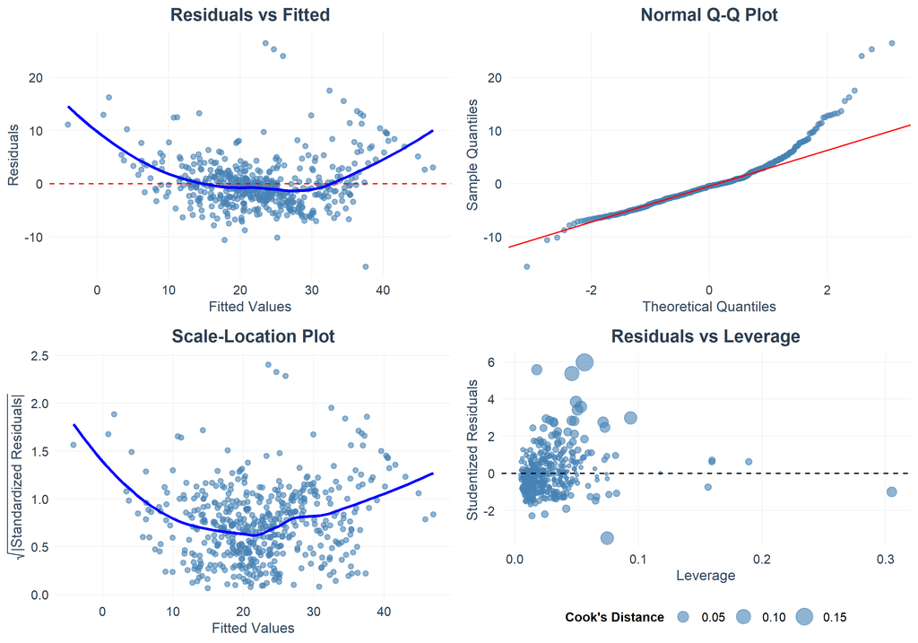

```r
library(ggplot2)
library(gridExtra)

# Diagnostic plots for the model_forward model

# Create diagnostic data set
residual_data <- data.frame(
  Fitted = fitted(model_forward),
  Residuals = residuals(model_forward),
  Standardized = rstandard(model_forward),
  Studentized = rstudent(model_forward)
)

# Residuals vs Fitted plot
p1 <- ggplot(residual_data, aes(x = Fitted, y = Residuals)) +
  geom_point(alpha = 0.6, color = "steelblue") +
  geom_hline(yintercept = 0, linetype = "dashed", color = "red") +
  geom_smooth(se = FALSE, method = "loess", color = "blue") +
  labs(title = "Residuals vs Fitted",
       x = "Fitted Values",
       y = "Residuals") +
  my.theme()

# Q-Q plot
p2 <- ggplot(residual_data, aes(sample = Residuals)) +
  stat_qq(alpha = 0.6, color = "steelblue") +
  stat_qq_line(color = "red") +
  labs(title = "Normal Q-Q Plot",
       x = "Theoretical Quantiles",
       y = "Sample Quantiles") +
  my.theme()

# Scale-Location plot
p3 <- ggplot(residual_data, aes(x = Fitted, y = sqrt(abs(Standardized)))) +
  geom_point(alpha = 0.6, color = "steelblue") +
  geom_smooth(se = FALSE, method = "loess", color = "blue") +
  labs(title = "Scale-Location Plot",
       x = "Fitted Values",
       y = expression(sqrt("|Standardized Residuals|"))) +
  my.theme()

# Residuals vs Leverage plot
residual_data$Leverage <- hatvalues(model_forward)
residual_data$CookSD <- cooks.distance(model_forward)

p4 <- ggplot(residual_data, aes(x = Leverage, y = Studentized)) +
  geom_point(aes(size = CookSD), alpha = 0.6, color = "steelblue") +
  geom_hline(yintercept = 0, linetype = "dashed") +
  labs(title = "Residuals vs Leverage",
       x = "Leverage",
       y = "Studentized Residuals") +
  scale_size_continuous("Cook's Distance") +
  my.theme()

grid.arrange(p1, p2, p3, p4, ncol = 2, nrow = 2)
```

The diagnostic plots suggest that the regression assumptions should be examined carefully. In particular, the Q-Q plot indicates some departure from normality, while the residual and scale-location plots can be used to assess possible nonlinearity and heteroscedasticity. Therefore, it is reasonable to investigate whether a Box-Cox transformation of `MEDV` can improve model fit。

## 5.3 Box-Cox Transformation

We perform a Box-Cox transformation based on the candidate model `model_forward`.

```r
suppressPackageStartupMessages(library(MASS))

# Re-read raw data fresh for Box-Cox step
boxcox_data <- read.csv("BostonHousing.csv")

# Remove exported index column if it exists
if ("Unnamed: 0" %in% names(boxcox_data)) {
  boxcox_data <- boxcox_data[, !(names(boxcox_data) %in% "Unnamed: 0")]
}

# Keep complete cases for modeling variables
boxcox_data <- boxcox_data[, c("MEDV", "CRIM", "ZN", "INDUS", "CHAS", "NOX",
                               "RM", "AGE", "DIS", "RAD", "TAX", "PTRATIO",
                               "B", "LSTAT", "LON", "LAT")]
boxcox_data <- na.omit(boxcox_data)

# Rebuild CHAS safely from raw 0/1 coding
boxcox_data$CHAS <- as.character(boxcox_data$CHAS)
boxcox_data$CHAS <- trimws(boxcox_data$CHAS)
boxcox_data$CHAS[boxcox_data$CHAS == "0"] <- "No"
boxcox_data$CHAS[boxcox_data$CHAS == "1"] <- "Yes"
boxcox_data <- boxcox_data[boxcox_data$CHAS %in% c("No", "Yes"), ]
boxcox_data$CHAS <- factor(boxcox_data$CHAS, levels = c("No", "Yes"))

# Check CHAS levels before fitting
print(table(boxcox_data$CHAS, useNA = "ifany"))
```

```
 No Yes
471  35
```

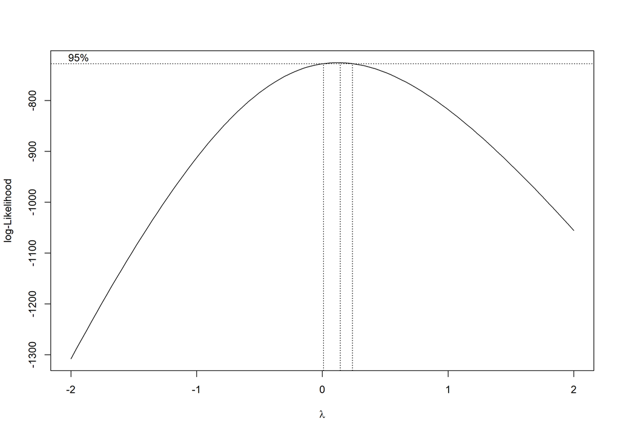

```r
# Refit full model on clean data
model_forward_clean <- lm(
  formula(model_forward),
  data = boxcox_data
)

# Perform Box-Cox transformation
boxcox_result <- boxcox(model_forward_clean, lambda = seq(-2, 2, length = 100))
```

```r
# Find optimal lambda
lambda_opt <- boxcox_result$x[which.max(boxcox_result$y)]
cat("Optimal lambda for Box-Cox transformation:", lambda_opt, "\n")
```

```
Optimal lambda for Box-Cox transformation: 0.1414
```

The Box-Cox result will be used to assess whether transforming MEDV is necessary. If the suggested $\lambda$ differs substantially from 1, we will consider an appropriate transformation of the response variable in the subsequent modeling step.

Some of the key goodness-of-fit metrics for the transformed model are summarized as follows.

```r
housing_clean$CHAS <- droplevels(housing_clean$CHAS)

if ("NOX_cat" %in% names(housing_clean)) {
  housing_clean$NOX_cat <- droplevels(housing_clean$NOX_cat)
}

if ("DIS_cat" %in% names(housing_clean)) {
  housing_clean$DIS_cat <- droplevels(housing_clean$DIS_cat)
}

if ("spatial_zone" %in% names(housing_clean)) {
  housing_clean$spatial_zone <- droplevels(housing_clean$spatial_zone)
}
```

**Caution:** Because AIC is calculated from the log-likelihood, and the log-likelihood depends on the scale of the response variable, the AIC values from the original model and the transformed model are **not directly comparable**.

```r
# Create transformed response variable
if(lambda_opt != 0) {
  housing_clean$MEDV_trans <- (housing_clean$MEDV^lambda_opt - 1) / lambda_opt
} else {
  housing_clean$MEDV_trans <- log(housing_clean$MEDV)
}

# Fit model with transformed response
model_transformed <- lm(
  MEDV_trans ~ CRIM + ZN + INDUS + CHAS + NOX + RM + AGE + DIS + RAD +
    TAX + PTRATIO + B + LSTAT + LON + LAT,
  data = housing_clean
)

# Compare original and transformed models
cat("\n=== Model Comparison ===\n\n",
    "Original model R-squared:", summary(model_forward)$r.squared, "\n\n",
    "Transformed model R-squared:", summary(model_transformed)$r.squared, "\n\n",
    "Original model AIC:", AIC(model_forward), "\n\n",
    "Transformed model AIC:", AIC(model_transformed), "\n")
```

```
=== Model Comparison ===

 Original model R-squared: 0.7437

 Transformed model R-squared: 0.7898

 Original model AIC: 3020

 Transformed model AIC: 202.1
```

# 6 Summary of Optimal Model

A multiple linear regression model was estimated to explain median house value (MEDV) using structural, environmental, accessibility, and spatial predictors from the Boston housing dataset. The final candidate model, obtained through the forward selection procedure, identifies a subset of variables that are useful for explaining variation in Boston housing values. Overall, the model suggests that housing value is associated with a combination of neighborhood quality, housing characteristics, environmental conditions, and location.

Overall, the model suggests that housing prices in the Boston area are shaped by a combination of structural, socioeconomic, environmental, and spatial factors. Although the model does not explain all of the variability in MEDV, it provides a meaningful summary of the main predictors associated with median housing value.